# Tutorial de IDW y splines con R

Gerardo

2023-02-27

# 1 Interpolación ponderada por el inverso de la distancia

Antes de la interpolación, es necesario formatear de manera especial los datos. La base que contiene la localidades de muestreo y las mediciones, tenemos que transformarla en un objeto reconocible por el paquete `sp`, de modo que sepa qué columnas contienen las coordenadas $x,y$, y cuáles los datos:

```r
library(gstat); library(raster)

puntos <- read.csv("../Datos-ejemplos/Datos-puntos-Moran.csv")

r.0 <- raster("../Datos-ejemplos/Var-1.tif")

datos.sp <- puntos
coordinates(datos.sp) <- ~ Longitud + Latitud
proj4string(datos.sp) <- CRS(proj4string(r.0))
```

Y hacemos lo mismo con el ráster de referencia, primero transformándolo en data.frame y luego en `SpatialPointsDataFrame`:

```r
new.data <- data.frame(rasterToPoints(r.0))[, 1:2]
names(new.data) <- c("Longitud", "Latitud")
coordinates(new.data) <- ~ Longitud + Latitud
proj4string(new.data) <- CRS(proj4string(r.0))
```

Nota que en ambos casos anteriores tuvimos que especificar qué sistema de coordenadas se usó, en este caso fue el datum WGS84 con número de identificación EPSG 4326.

Y ahora sí, corremos la rutina de interpolación con la función `idw` (inverse distance weighted) de `gstat`.

```r
inv.dist <- idw(formula = Mediciones ~ 1, locations = datos.sp, newdata = new.data)
```

```
## [inverse distance weighted interpolation]
```

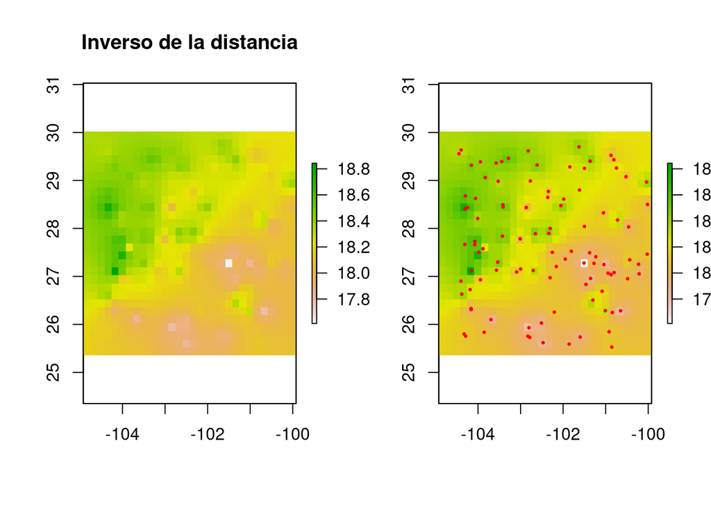

Figure 1.1: Interpolación por inverso de la distancia.

```r
r.idw <- rasterFromXYZ(data.frame(coordinates(new.data), inv.dist$var1.pred))

#Gráfica
par(mfrow = c(1, 2))
plot(r.idw, main = "Inverso de la distancia")
plot(r.idw)
points(datos.sp, pch = 20, col = "red", cex = 0.5)
```

# 2 Regresión sobre las coordenadas con splines

Anteriormente vimos cómo interpolar haciendo regresión sobre las coordenadas, lo cual sólo es efectivo si existen gradientes lineales en relación a la longitud y latitud. Sin embargo, en la inmensa mayoría de las situaciones existirán estructuras topográficas y atributos geográficos que harán que las relaciones entre lo que medimos y las coordenadas sean no lineales. Por lo tanto, una herramienta más útil que la regresión lineal son los splines implementada en R por medio de modelos lineales aditivos.

Para estos análisis podemos utilizar todos los objetos que ya formateamos hasta ahora. Las funciones para ajustar modelos lineales aditivos están en el paquete `mgcv`, instalado por defecto con R, en la función `gam` (generalised additive model). Por defecto, las fórmulas que se usan en `gam` son idénticas a las que se usan en `lm` (modelo lineal). Para que una variable pueda estimar relaciones no lineales, necesitamos espacificar con otras funciones el tipo de splines que se. Veamos:

```r
library(mgcv)
spl <- gam(Mediciones ~ s(Longitud, Latitud, k = 25), data = puntos)
```

donde s es la función suavizadora o spline, y k es el número de nodos que habrá en cada variable. Yo decidí arbitrariamente utilizar 25 nodos, pero en realidad puede haber objetivamente más o menos nodos. Los nodos son puntos igualmente espaciados en el rango de valores de cada variable en los cuales se estimarán parámetros del spline. Por ejemplo, para Longitud -100 – -101, un parámetro, y otro para -101 – -102.

Para ver las predicciones de `gam`:

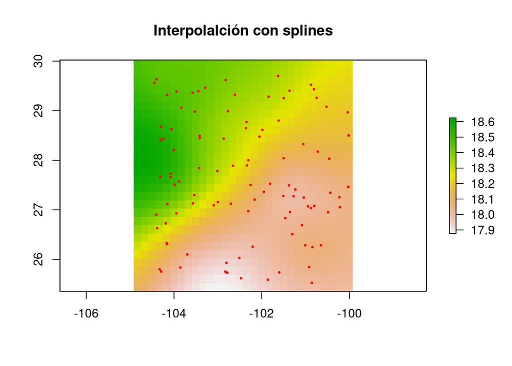

Figure 2.1: Resultado de la interpolación con splines en un modelo aditivo generalizado, haciendo regresión sobre las coordenadas.

```r
spl.pred <- predict(spl, newdata = data.frame(coordinates(new.data)))

r.spl <- rasterFromXYZ(data.frame(coordinates(new.data), spl.pred))

plot(r.spl, main = "Interpolalción con splines")
points(datos.sp, pch = 20, col = "red", cex = 0.5)
```

Otra implementaciín de splines, incluso más adecuada para la interpolación espacial, se llama Thin Plate Spline, disponible con la función `Tps` en el paquete `fields`.

# 3 Otros tipos de interpolación

1. Bicúbico
2. Bilineal
3. Kriging
4. Regresión-Kriging

Regresar al índice del curso